# Risk Factor Analysis

## Outcome Variable

**Outcome Variable:** sstunted

## Predictor Variables

**Intervention Variable:** fhtcm

**Adjustment Set:**

unadjusted

## Stratifying Variables

The analysis was stratified on these variable(s):

- agecat
- studyid

The following strata were considered:

- agecat: 12 months, studyid: ki1000304b-SAS-FoodSuppl
- agecat: 12 months, studyid: ki1101329-Keneba
- agecat: 12 months, studyid: ki1135781-COHORTS
- agecat: 18 months, studyid: ki1000304b-SAS-FoodSuppl
- agecat: 18 months, studyid: ki1101329-Keneba
- agecat: 18 months, studyid: ki1135781-COHORTS
- agecat: 24 months, studyid: ki1101329-Keneba
- agecat: 24 months, studyid: ki1135781-COHORTS
- agecat: 3 months, studyid: ki1000304b-SAS-FoodSuppl
- agecat: 3 months, studyid: ki1101329-Keneba
- agecat: 3 months, studyid: ki1135781-COHORTS
- agecat: 6 months, studyid: ki1000304b-SAS-FoodSuppl
- agecat: 6 months, studyid: ki1101329-Keneba
- agecat: 6 months, studyid: ki1135781-COHORTS
- agecat: 9 months, studyid: ki1000304b-SAS-FoodSuppl
- agecat: 9 months, studyid: ki1101329-Keneba
- agecat: 9 months, studyid: ki1135781-COHORTS
- agecat: Birth, studyid: ki1101329-Keneba
- agecat: Birth, studyid: ki1135781-COHORTS

### Dropped Strata

Some strata were dropped due to rare outcomes:

- agecat: Birth, studyid: ki1101329-Keneba
- agecat: Birth, studyid: ki1135781-COHORTS
- agecat: 3 months, studyid: ki1000304b-SAS-FoodSuppl
- agecat: 3 months, studyid: ki1101329-Keneba
- agecat: 3 months, studyid: ki1135781-COHORTS
- agecat: 6 months, studyid: ki1000304b-SAS-FoodSuppl
- agecat: 6 months, studyid: ki1101329-Keneba
- agecat: 6 months, studyid: ki1135781-COHORTS
- agecat: 9 months, studyid: ki1000304b-SAS-FoodSuppl
- agecat: 9 months, studyid: ki1101329-Keneba
- agecat: 9 months, studyid: ki1135781-COHORTS
- agecat: 12 months, studyid: ki1000304b-SAS-FoodSuppl
- agecat: 12 months, studyid: ki1101329-Keneba
- agecat: 12 months, studyid: ki1135781-COHORTS
- agecat: 18 months, studyid: ki1000304b-SAS-FoodSuppl
- agecat: 18 months, studyid: ki1135781-COHORTS
- agecat: 24 months, studyid: ki1101329-Keneba
- agecat: 24 months, studyid: ki1135781-COHORTS

## Methods Detail

We’re interested in the causal parameters $E[Y_a]$ for all values of $a \in \mathcal{A}$. These parameters represent the mean outcome if, possibly contrary to fact, we intervened to set all units to have $A=a$. Under the randomization and positivity assumptions, these are identified by the statistical parameters $\psi_a=E_W[E_{Y|A,W}(Y|A=a,W)]$. In addition, we’re interested in the mean of $Y$, $E[Y]$ under no intervention (the observed mean). We will estimate these parameters by using SuperLearner to fit the relevant likelihood factors – $E_{Y|A,W}(Y|A=a,W)$ and $p(A=a|W)$, and then updating our likelihood fit using a joint TMLE.

For unadjusted analyses ($W=\{\}$), initial likelihoods were estimated using Lrnr_glm to estimate the simple $E(Y|A)$ and Lrnr_mean to estimate $p(A)$. For adjusted analyses, a small library containing Lrnr_glmnet, Lrnr_xgboost, and Lrnr_mean was used.

Having estimated these parameters, we will then use the delta method to estimate relative risks and attributable risks relative to a prespecified baseline level of $A$.

# Results Detail

## Results Plots

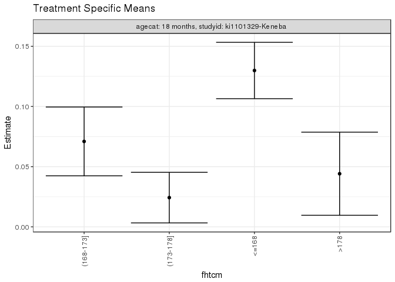

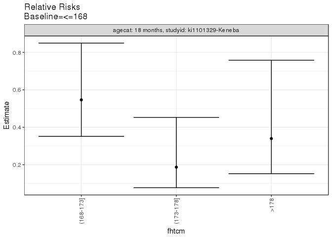

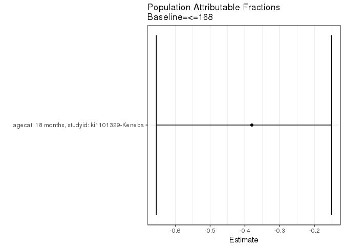

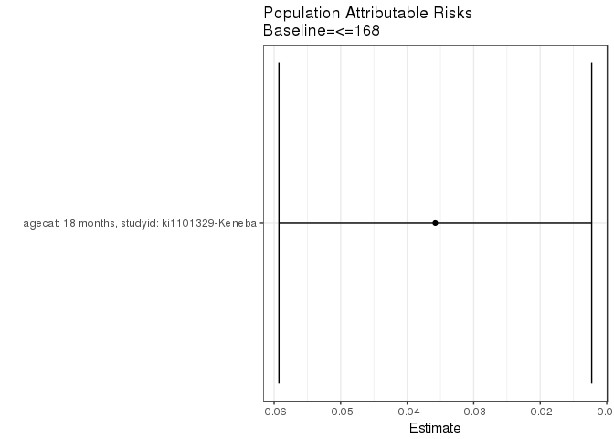

## Data Summary

| agecat | studyid | A | n | nA | nAY0 | nAY1 |
| --- | --- | --- | --- | --- | --- | --- |
| Birth | ki1000304b-SAS-FoodSuppl | <=168 | 0 | 0 | 0 | 0 |
| Birth | ki1000304b-SAS-FoodSuppl | (168-173] | 0 | 0 | 0 | 0 |
| Birth | ki1000304b-SAS-FoodSuppl | (173-178] | 0 | 0 | 0 | 0 |
| Birth | ki1000304b-SAS-FoodSuppl | >178 | 0 | 0 | 0 | 0 |
| Birth | ki1101329-Keneba | <=168 | 1165 | 609 | 599 | 10 |
| Birth | ki1101329-Keneba | (168-173] | 1165 | 252 | 248 | 4 |
| Birth | ki1101329-Keneba | (173-178] | 1165 | 179 | 176 | 3 |
| Birth | ki1101329-Keneba | >178 | 1165 | 125 | 121 | 4 |
| Birth | ki1135781-COHORTS | <=168 | 91 | 85 | 85 | 0 |
| Birth | ki1135781-COHORTS | (168-173] | 91 | 5 | 3 | 2 |
| Birth | ki1135781-COHORTS | (173-178] | 91 | 1 | 1 | 0 |
| Birth | ki1135781-COHORTS | >178 | 91 | 0 | 0 | 0 |
| 3 months | ki1000304b-SAS-FoodSuppl | <=168 | 92 | 79 | 69 | 10 |
| 3 months | ki1000304b-SAS-FoodSuppl | (168-173] | 92 | 8 | 7 | 1 |
| 3 months | ki1000304b-SAS-FoodSuppl | (173-178] | 92 | 4 | 4 | 0 |
| 3 months | ki1000304b-SAS-FoodSuppl | >178 | 92 | 1 | 1 | 0 |
| 3 months | ki1101329-Keneba | <=168 | 1562 | 831 | 801 | 30 |
| 3 months | ki1101329-Keneba | (168-173] | 1562 | 331 | 323 | 8 |
| 3 months | ki1101329-Keneba | (173-178] | 1562 | 239 | 237 | 2 |
| 3 months | ki1101329-Keneba | >178 | 1562 | 161 | 155 | 6 |
| 3 months | ki1135781-COHORTS | <=168 | 140 | 128 | 112 | 16 |
| 3 months | ki1135781-COHORTS | (168-173] | 140 | 6 | 5 | 1 |
| 3 months | ki1135781-COHORTS | (173-178] | 140 | 6 | 6 | 0 |
| 3 months | ki1135781-COHORTS | >178 | 140 | 0 | 0 | 0 |
| 6 months | ki1000304b-SAS-FoodSuppl | <=168 | 94 | 81 | 71 | 10 |
| 6 months | ki1000304b-SAS-FoodSuppl | (168-173] | 94 | 8 | 5 | 3 |
| 6 months | ki1000304b-SAS-FoodSuppl | (173-178] | 94 | 4 | 3 | 1 |
| 6 months | ki1000304b-SAS-FoodSuppl | >178 | 94 | 1 | 1 | 0 |
| 6 months | ki1101329-Keneba | <=168 | 1511 | 799 | 767 | 32 |
| 6 months | ki1101329-Keneba | (168-173] | 1511 | 312 | 298 | 14 |

[output cut: 54 more lines]

## Results Table

### Parameter: TSM

| agecat | studyid | intervention_level | baseline_level | estimate | ci_lower | ci_upper |
| --- | --- | --- | --- | --- | --- | --- |
| 18 months | ki1101329-Keneba | <=168 | NA | 0.1298865 | 0.1064803 | 0.1532928 |
| 18 months | ki1101329-Keneba | (168-173] | NA | 0.0709677 | 0.0423745 | 0.0995610 |
| 18 months | ki1101329-Keneba | (173-178] | NA | 0.0242718 | 0.0032495 | 0.0452942 |
| 18 months | ki1101329-Keneba | >178 | NA | 0.0441176 | 0.0095924 | 0.0786429 |

### Parameter: E(Y)

| agecat | studyid | intervention_level | baseline_level | estimate | ci_lower | ci_upper |
| --- | --- | --- | --- | --- | --- | --- |
| 18 months | ki1101329-Keneba | NA | NA | 0.0941176 | 0.0919613 | 0.096274 |

### Parameter: RR

| agecat | studyid | intervention_level | baseline_level | estimate | ci_lower | ci_upper |
| --- | --- | --- | --- | --- | --- | --- |
| 18 months | ki1101329-Keneba | (168-173] | <=168 | 0.5463827 | 0.3514091 | 0.8495343 |
| 18 months | ki1101329-Keneba | (173-178] | <=168 | 0.1868696 | 0.0771494 | 0.4526318 |
| 18 months | ki1101329-Keneba | >178 | <=168 | 0.3396630 | 0.1521551 | 0.7582458 |

### Parameter: PAR

| agecat | studyid | intervention_level | baseline_level | estimate | ci_lower | ci_upper |
| --- | --- | --- | --- | --- | --- | --- |
| 18 months | ki1101329-Keneba | <=168 | NA | -0.0357689 | -0.0592742 | -0.0122635 |

### Parameter: PAF

| agecat | studyid | intervention_level | baseline_level | estimate | ci_lower | ci_upper |
| --- | --- | --- | --- | --- | --- | --- |
| 18 months | ki1101329-Keneba | <=168 | NA | -0.3800441 | -0.6549511 | -0.1508025 |